# Analysis of Weather Events in the United States (Reproducible Research: Peer Assessment 2)

DSCourse001 User

Friday, June 19, 2015

## Synopsis

This document should answer on the following questions.

1. Across the United States, which types of events are most harmful with respect to population health?
2. Across the United States, which types of events have the greatest economic consequences?

Data, that was used in calculations, can be obtained following [this link](https://d396qusza40orc.cloudfront.net/repdata%2Fdata%2FStormData.csv.bz2).

The events in the database start in the year 1950 and end in November 2011. In the earlier years of the database there are generally fewer events recorded, most likely due to a lack of good records. More recent years should be considered more complete.

There is also some documentation of the database available.

1. National Weather [Service Storm Data Documentation](https://d396qusza40orc.cloudfront.net/repdata%2Fpeer2_doc%2Fpd01016005curr.pdf)
2. National Climatic Data Center Storm Events [FAQ](https://d396qusza40orc.cloudfront.net/repdata%2Fpeer2_doc%2FNCDC%20Storm%20Events-FAQ%20Page.pdf)

## Data Processing

Data came in csv file which is compressed in bz2 format. Unfortunately that file cannot be loaded using “fast” loading tools like `fread` because of End-Of-Line character used in remarks. We can say that we need only few columns from the original data set. Additionally As we will see data is skewed and there should be done additional processing to make data understandable for machine language.

Columns that we need:

- EVTYPE - Type of weather event
- FATALITIES - Number of fatalities that this event cause
- INJURIES - Number of injuries that this event cause
- PROPDMG - Damage of property that this event cause
- PROPDMGEXP - Multiplication factor for PROPDMG
- CROPDMG - Damage of crop that this event cause
- CROPDMGEXP - Multiplication factor for CROPDMG

After formatting the data we will produce new data set with sammary which one we will use to plot the data.

1. Loading data from bz2 archive

First of all we need to load required R packages and setup document parameters.

```r
require(knitr)
require(data.table)
require(dplyr)
require(plyr)
require(ggplot2)
require(grid)
require(gridExtra)

opts_knit$set(root.dir = ".")
opts_chunk$set(fig.path = "./figure/",dev="png")
```

Now we can load data from the internet.

```r
## Reading csv file in bz2 archive and convert to data.table class
url<-"https://d396qusza40orc.cloudfront.net/repdata%2Fdata%2FStormData.csv.bz2"
bzfileName<-tempfile()
download.file(url=url,destfile=bzfileName,method="wget",quiet=T,mode="wb",extra=c("--no-check-certificate"))

data<-as.data.table(
    read.csv(
        bzfile<-bzfile(bzfileName,open="r")
        ,stringsAsFactor=F,header=T
        )
    )

close(bzfile)
unlink(bzfileName)
```

2. Processing data. Please read comments to R Code.

```r
## Getting Event Type, Time, Country Name and State,
## Fatalities and Injuries of people,
## Damage for Property and Crop
data<-data[,list(EVTYPE
                 ,FATALITIES,INJURIES
                 ,PROPDMG,PROPDMGEXP,CROPDMG,CROPDMGEXP
                 )]

## Let walk through the data
table(is.na(data))
```

```
##
##   FALSE
## 6316079
```

```r
## There is some problem with Event Type
length(unique(data$EVTYPE))
```

```
## [1] 985
```

```r
length(unique(toupper(data$EVTYPE)))
```

```
## [1] 898
```

```r
## Multiplication Factor for Property and Crop Damage came in different format
## For Property Damage
sort(unique(data$PROPDMGEXP))
```

```
##  [1] ""  "-" "?" "+" "0" "1" "2" "3" "4" "5" "6" "7" "8" "B" "h" "H" "K"
## [18] "m" "M"
```

```r
## For Crop Damage
sort(unique(data$CROPDMGEXP))
```

```
## [1] ""  "?" "0" "2" "B" "k" "K" "m" "M"
```

```r
## Let Assign Data
## Re-assign data to avoid output
data<-data[,`:=` (
PROPDMG=as.numeric(mapvalues(toupper(PROPDMGEXP),
c("","-","?","+","0","1","2","3","4","5","6","7","8","9","H","K","M","B"),
c(rep(1,5),1e1,1e2,1e3,1e4,1e5,1e6,1e7,1e8,1e9,1e2,1e3,1e6,1e9)
)) * PROPDMG,
CROPDMG=as.numeric(mapvalues(toupper(CROPDMGEXP),
c("","-","?","+","0","1","2","3","4","5","6","7","8","9","H","K","M","B"),
c(rep(1,5),1e1,1e2,1e3,1e4,1e5,1e6,1e7,1e8,1e9,1e2,1e3,1e6,1e9)
)) * CROPDMG,
PROPDMGEXP=NULL,CROPDMGEXP=NULL
)]

## Total Damage
data<-data[,TOTALDMG:=PROPDMG+CROPDMG]

## Event Type
data<-data[,EVTYPE:=toupper(EVTYPE)]

## Translate Column Names to Lower Case
setnames(data,tolower(names(data)))

## Now Data is ready to processing
str(data)
```

```
## Classes 'data.table' and 'data.frame':   902297 obs. of  6 variables:
##  $ evtype    : chr  "TORNADO" "TORNADO" "TORNADO" "TORNADO" ...
##  $ fatalities: num  0 0 0 0 0 0 0 0 1 0 ...
##  $ injuries  : num  15 0 2 2 2 6 1 0 14 0 ...
##  $ propdmg   : num  25000 2500 25000 2500 2500 2500 2500 2500 25000 25000 ...
##  $ cropdmg   : num  0 0 0 0 0 0 0 0 0 0 ...
##  $ totaldmg  : num  25000 2500 25000 2500 2500 2500 2500 2500 25000 25000 ...
##  - attr(*, ".internal.selfref")=<externalptr>
```

```r
## Before Plot we would like to create few data sets for summary data
dataGroup <- data %>%
                group_by(evtype) %>%
                    summarise_each(funs(sum)
                                   ,fatalities,injuries
                                   ,propdmg,cropdmg,totaldmg)

## And let us take few marks
fatalitiesMost<-arrange(dataGroup,-fatalities)$evtype[1]
injuriesMost<-arrange(dataGroup,-injuries)$evtype[1]
propdmgMost<-arrange(dataGroup,-propdmg)$evtype[1]
cropdmgMost<-arrange(dataGroup,-cropdmg)$evtype[1]
totaldmgMost<-arrange(dataGroup,-totaldmg)$evtype[1]
```

## Results

Results are visualized on graphs.

1. We can see that **TORNADO** caused the most injuries, and **TORNADO** is the most harmful with respect to population health.
2. **FLOOD** caused the most damage to property, **DROUGHT** caused the most damage to crop. But the **FLOOD** Caused the most damage with respect to property and crop damage totally.

### Top 5 Events by fatalities and injuries.

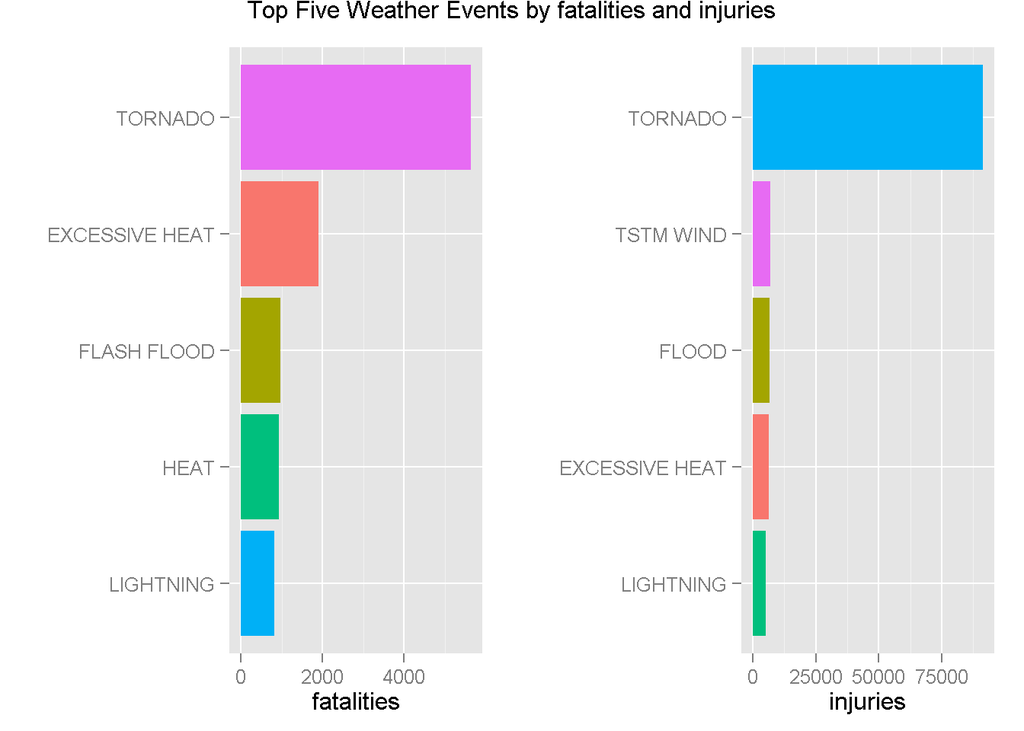

```r
plot1<-ggplot(
  data=head(plyr::arrange(dataGroup,-fatalities),5),
  aes(x=reorder(evtype,fatalities),y=fatalities,fill=evtype)) +
  geom_bar(stat="identity") +
  coord_flip() +
  theme(legend.position="none") +
  labs(x="")

plot2<-ggplot(
  data=head(arrange(dataGroup,-injuries),5),
  aes(x=reorder(evtype,injuries),y=injuries,fill=evtype)) +
  geom_bar(stat="identity") +
  coord_flip() +
  theme(legend.position="none") +
  labs(x="")

grid.arrange(plot1,plot2,ncol=2,main="Top Five Weather Events by fatalities and injuries")
```

### Top 5 Events by Damage to Property and Crop

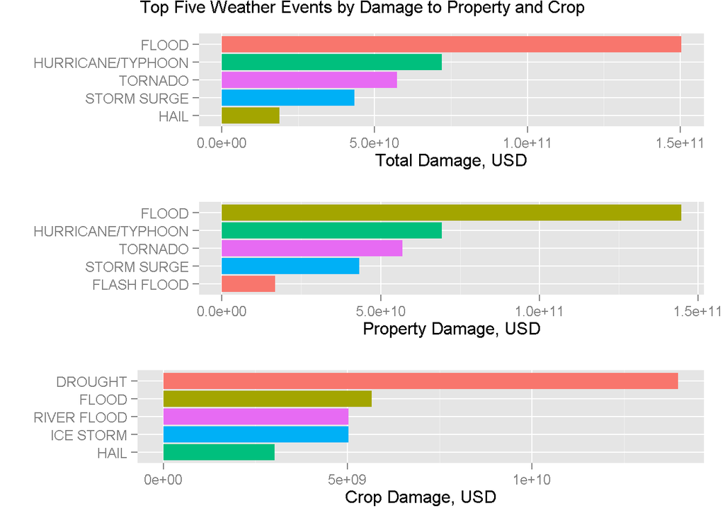

```r
plot1<-ggplot(
  data=head(arrange(dataGroup,-propdmg),5),
  aes(x=reorder(evtype,propdmg),y=propdmg,fill=evtype)) +
  geom_bar(stat="identity") +
  coord_flip() +
  theme(legend.position="none") +
  labs(x="",y="Property Damage, USD")

plot2<-ggplot(
  data=head(arrange(dataGroup,-cropdmg),5),
  aes(x=reorder(evtype,cropdmg),y=cropdmg,fill=evtype)) +
  geom_bar(stat="identity") +
  coord_flip() +
  theme(legend.position="none") +
  labs(x="",y="Crop Damage, USD")

plot3<-ggplot(
  data=head(arrange(dataGroup,-totaldmg),5),
  aes(x=reorder(evtype,totaldmg),y=totaldmg,fill=evtype)) +
  geom_bar(stat="identity") +
  coord_flip() +
  theme(legend.position="none") +
  labs(x="",y="Total Damage, USD")

grid.arrange(plot3,plot1,plot2,nrow=3,main="Top Five Weather Events by Damage to Property and Crop")
```

## Conclusion

We have cleared up initial data and prepare for plotting. After that we have drown plots that answers on question in the beginning of this investigation.